# RNAseq analysis of Aspergillus Parasiticus MM36 grown with alkanes

Author

Romanos Siaperas

Published

December 14, 2024

## 1 Introduction

### 1.1 The paper

*Aspergillus parasiticus* MM36, isolated from *T. molitor* intestines, can grow using a mixture of long-chain alkanes (lcAlk), ranging from C24 to C36, as the sole carbon source. Additionally, its lcAlk-induced secretome can cause structural modifications on polyethylene (Taxeidis et al., 2023). To gain deeper insights into this strain’s capabilities, we employed a multi-omics approach, starting with genome sequencing, assembly and annotation. We performed RNAseq to investigate the molecular response during lcAlk assimilation. Secretome analysis with LC-MS/MS provided further insights into the enzymes involved in lcAlk and PE modification. This offers a comprehensive view of alkane metabolism by filamentous fungi, highlighting its relevance to plastic degradation.

Total RNA was extracted from each timepoint in triplicates by Novogene, the polyA+ fraction was purified, and libraries were constructed with the Novogene NGS RNA Library Prep Set (PT042)* kit and sequenced in paired-end mode on a NovaSeq 6000. One hexadecane sample with a RIN value of 3.7 was discarded leaving this condition with two replicates. Raw data were processed using nf-core/rnaseq v3.10.1 (10.5281/zenodo.1400710) of the nf-core collection of workflows (Ewels et al., 2020) at the high-performance computing bioinformatics platform of HCMR (Crete, Greece) (Zafeiropoulos et al., 2021).

### 1.2 The data

- The salmon quantification data and the salmon_tx2gene.tsv (mapping of isoforms to genes, in this annotation there is one isoform per gene) have been deposited to the NCBI Gene Expression Omnibus (GEO) database with the dataset identifier GSE282836.
- The genome project is in GenBank with accession [JAWDVE000000000](https://www.ncbi.nlm.nih.gov/datasets/genome/GCA_037075405.1/).
- [go‐basic.obo](https://release.geneontology.org/2023-04-01/ontology/go-basic.obo)

**When published will add links to download the files from GEO ftp and a script to download all data.**

### 1.3 The analysis

We have three conditions with three or two replicates. The conditions are:

- secretome after growth with long-chain alkanes for 2 days (lcAlk_2d) with 3 replicates
- secretome after growth with long-chain alkanes for 3 days (lcAlk_3d) with 3 replicates
- secretome after growth with hexadecane for 3 days (C16_3d) with 2 replicates (one was discarded due to low RIN)

The data analysis will start with the salmon transcript-level counts, the output of nf-core/rnaseq v3.10.1:

- one quant.sf.gz file per sample
- the mapping of isoforms to genes salmon_tx2gene.tsv.gz (here we have one per gene)

## 2 Load data

Raw counts will be loaded in edgeR v3.43.4.

```r
library(edgeR)
library(tidyverse)
library(tximport)


samples <- c("C16_D3B", "C16_D3C","Alkanes_D2A", "Alkanes_D2B", "Alkanes_D2C", "Alkanes_D3A", "Alkanes_D3B", "Alkanes_D3C")
conditions <- factor(sub(".$", "", samples))

### Summarize transcript-level salmon output to gene-level with tximport
files <- paste("data/RNAseq/", samples, ".quant.sf.gz", sep = "")
names(files) <- samples
tx2gene <- read.csv("data/RNAseq/salmon_tx2gene.tsv.gz", sep = '\t', header = FALSE)
txi <- tximport(files, type = "salmon", tx2gene = tx2gene)
sampleTable <- data.frame(condition = factor(conditions))
rownames(sampleTable) <- colnames(txi$counts)
```

```r
#| layout-ncol: 2
#| layout-nrow: 1
#| column: page
#| echo: true

##### Load in edgeR to run edgeR-exact followwing recomemendations for few replicates 10.1261/rna.053959.115.  ####
cts <- txi$counts
paste("Genes with 0 counts in all samples:", sum(rowSums(cts) == 0))
```

```
[1] "Genes with 0 counts in all samples: 57"
```

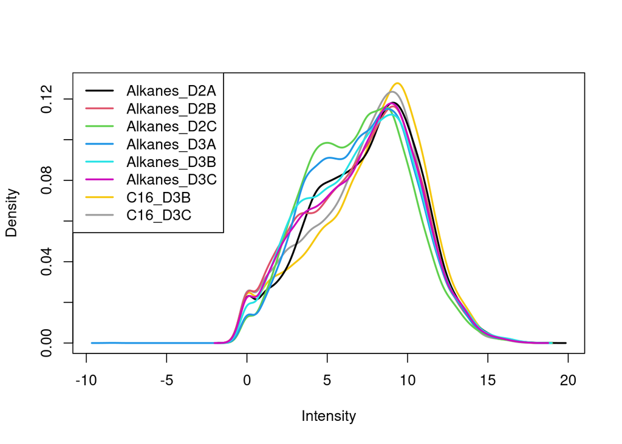

Figure 1: Density of log2 raw data

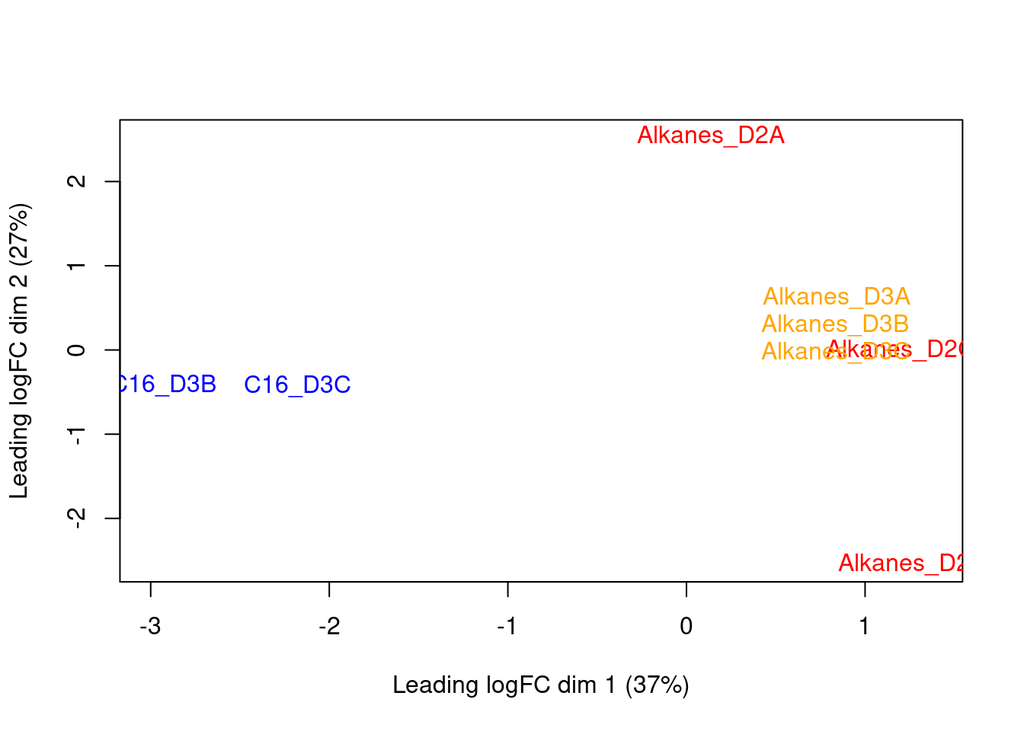

Figure 2: MDS of log2 raw data

```r
normMat <- txi$length
limma::plotDensities(log2(cts), main = "")
limma::plotMDS(log2(cts), col = c(rep(c("blue", "blue")),rep(c('red', 'orange'), each = 3) ), main = "")
```

## 3 Filter & TMM normalize

Raw counts were loaded in edgeR v3.43.4 and were normalized using the TMM normalization (Robinson et al., 2010). Based on Chen et. al. (Chen et al., 2016) genes with low expression were excluded. Specifically, only genes with more than 10/L reads, where L = 16,66 represents the median library size in millions, in at least two replicates of any condition were retained for downstream analysis. 11964 genes (86%) passed this filtering.

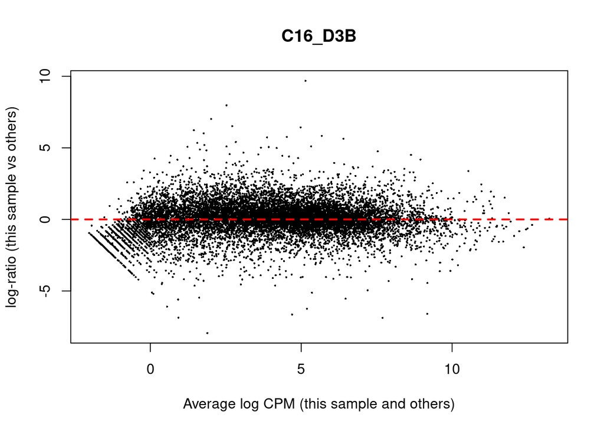

Figure 3

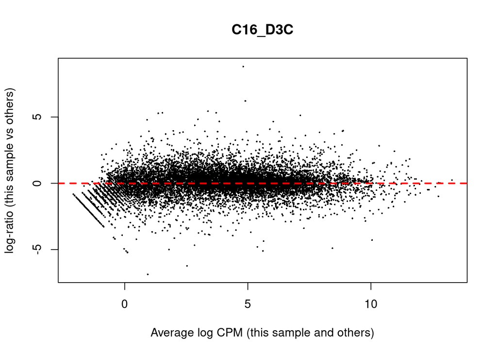

Figure 4

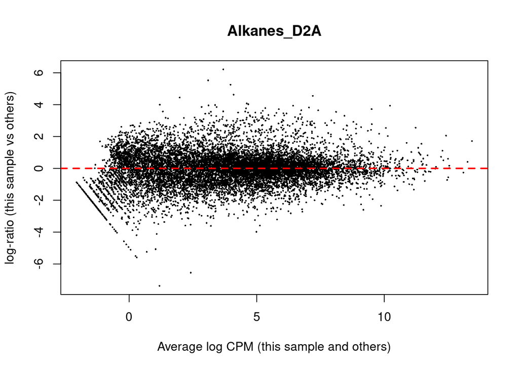

Figure 5

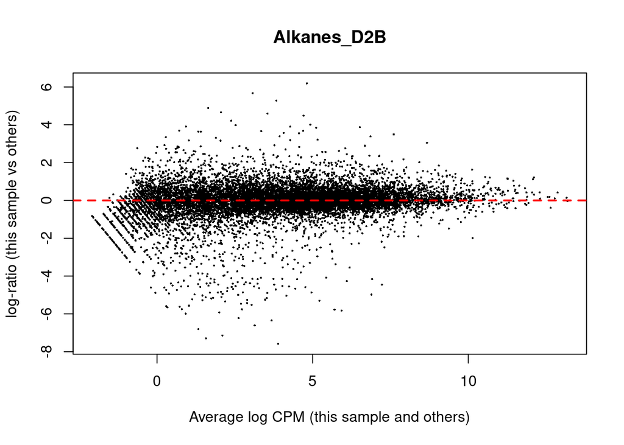

Figure 6

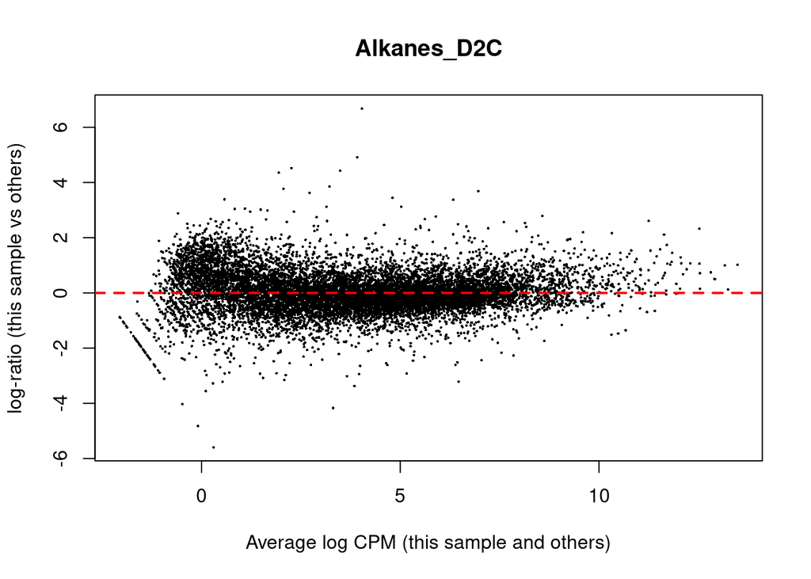

Figure 7

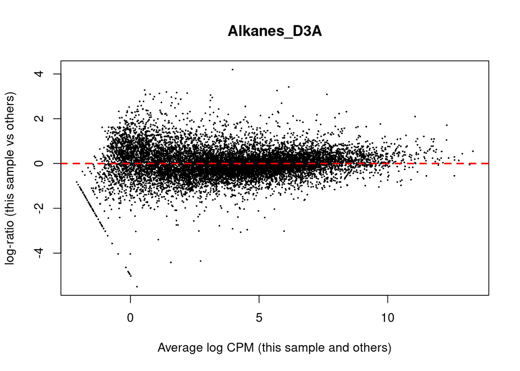

Figure 8

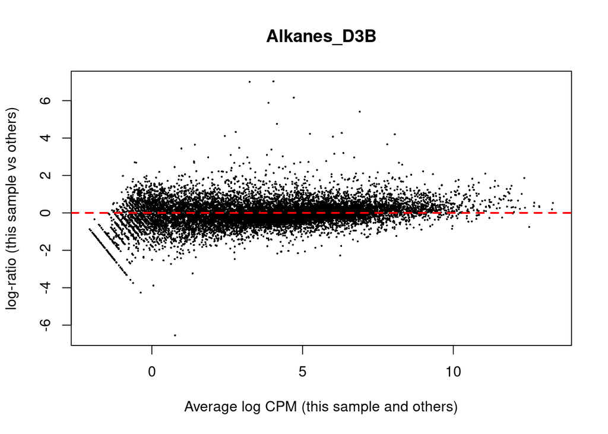

Figure 9

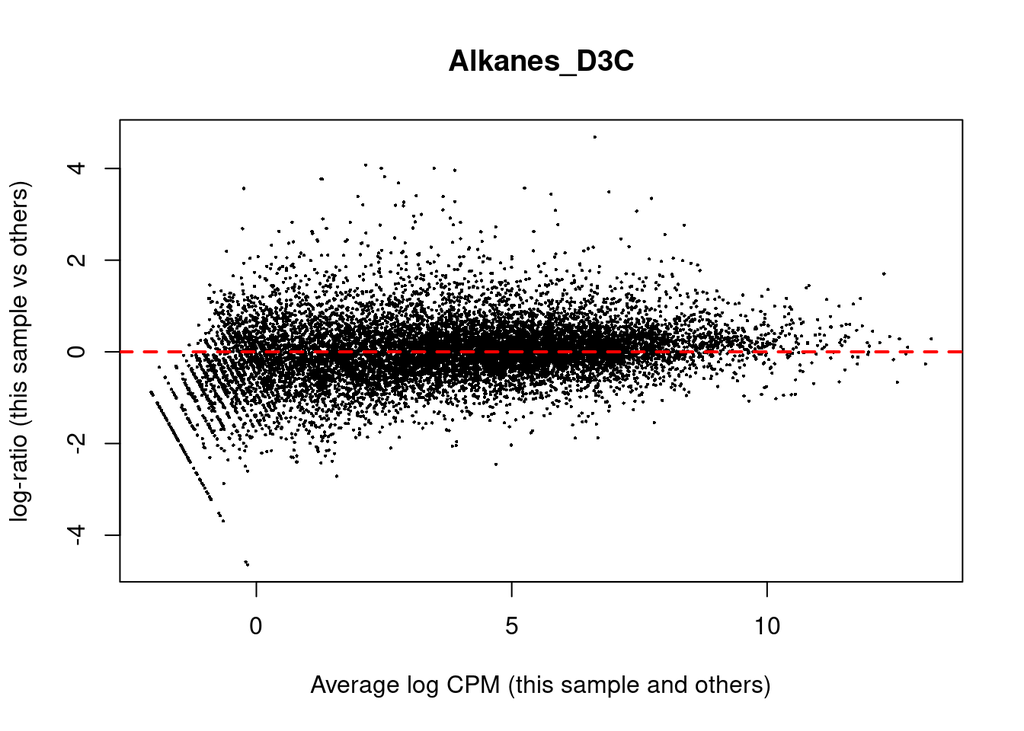

Figure 10

```r
# Obtaining per-observation scaling factors for length, adjusted to avoid changing the magnitude of the counts.
normMat <- normMat/exp(rowMeans(log(normMat)))
normCts <- cts/normMat

# Computing effective library sizes from scaled counts, to account for composition biases between samples.
eff.lib <- calcNormFactors(normCts) * colSums(normCts)

# Combining effective library sizes with the length factors, and calculating offsets for a log-link GLM.
normMat <- sweep(normMat, 2, eff.lib, "*")
normMat <- log(normMat)

# Creating a DGEList object for use in edgeR.
y <- DGEList(cts, group = conditions)
y <- scaleOffset(y, normMat)
all_genes_count <-  y$counts %>% nrow()

# Keep genes present in 2 samples of at least one condition ####
# cpm threshold is 10/L where L is the median libraly size in millions
CPM.Cutoff <- 10 / median(y$samples$lib.size) *1e6
#print(paste0(CPM.Cutoff," is the CPM cutoff."))

keep_1 <- rowSums(cpm(y[,1:2]) > CPM.Cutoff) >= 2 - 1e-14
keep_2 <- rowSums(cpm(y[,3:5]) > CPM.Cutoff) >= 2 - 1e-14
keep_3 <- rowSums(cpm(y[,6:8]) > CPM.Cutoff) >= 2 - 1e-14
all_y <- y
y <- y[keep_1 | keep_2 | keep_3, , keep.lib.sizes=FALSE]
filtered_genes_count <-  y$counts %>% nrow()
# save the genes passing the filtering, they are the background population for enrichment analysis later
write.table(rownames(y$counts), file = "results/RNAseq/population", row.names = FALSE, col.names = FALSE, quote = FALSE)

### MD plots
plotMD(y, column=1)
abline(h=0, col="red", lty=2, lwd=2)
plotMD(y, column=2)
abline(h=0, col="red", lty=2, lwd=2)
plotMD(y, column=3)
abline(h=0, col="red", lty=2, lwd=2)
plotMD(y, column=4)
abline(h=0, col="red", lty=2, lwd=2)
plotMD(y, column=5)
abline(h=0, col="red", lty=2, lwd=2)
plotMD(y, column=6)
abline(h=0, col="red", lty=2, lwd=2)
plotMD(y, column=7)
abline(h=0, col="red", lty=2, lwd=2)
plotMD(y, column=8)
abline(h=0, col="red", lty=2, lwd=2)

#print(paste0(filtered_genes_count," genes passed the filtering (", round(filtered_genes_count / all_genes_count, 2) * 100, "%)"))
```

## 4 Differential expression testing

Differential expression (DE) was tested with the edgeR-exact test following recommendations for few replicates (Schurch et al., 2016). The p-value was adjusted with the Benjamini-Hochberg (B-H) correction and corresponds to an FDR of 5 %.

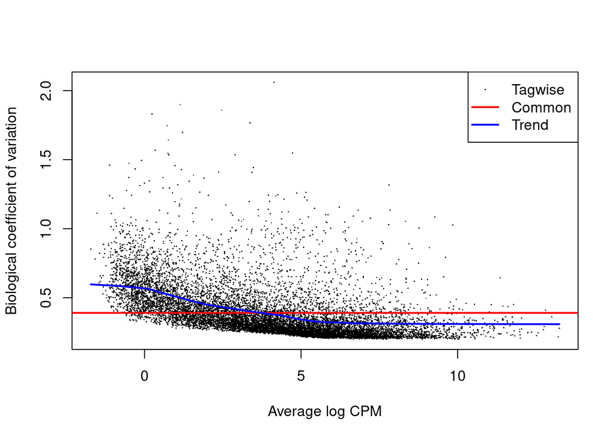

Figure 11: Biological coefficient of variation

```r
# create design
design <- model.matrix(~0+ conditions)
colnames(design) <- levels(conditions)

# estimate dispersion
y <- estimateDisp(y, design, robust=TRUE)
plotBCV(y)
```

```
       Alkanes_D3-C16_D3
Down                2222
NotSig              8615
Up                  1127
```

```
       Alkanes_D3-Alkanes_D2
Down                     104
NotSig                 11729
Up                       131
```

```
       Alkanes_D2-C16_D3
Down                1800
NotSig              9114
Up                  1050
```

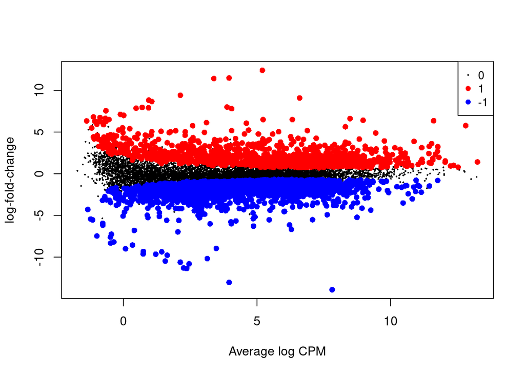

Figure 12: Alkanes_D3 vs C16_D3

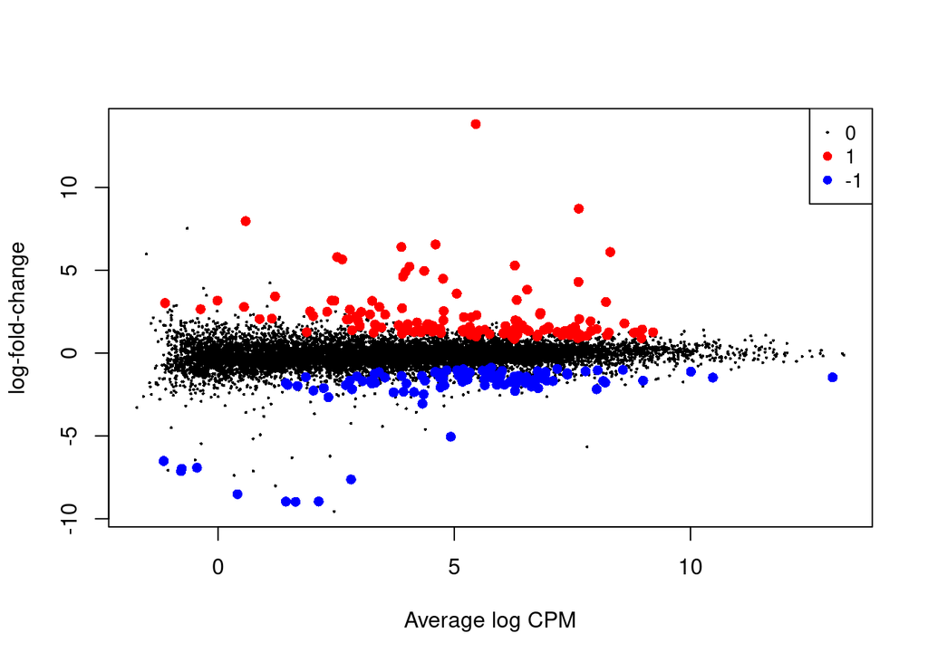

Figure 13: Alkanes_D3 vs Alkanes_D2

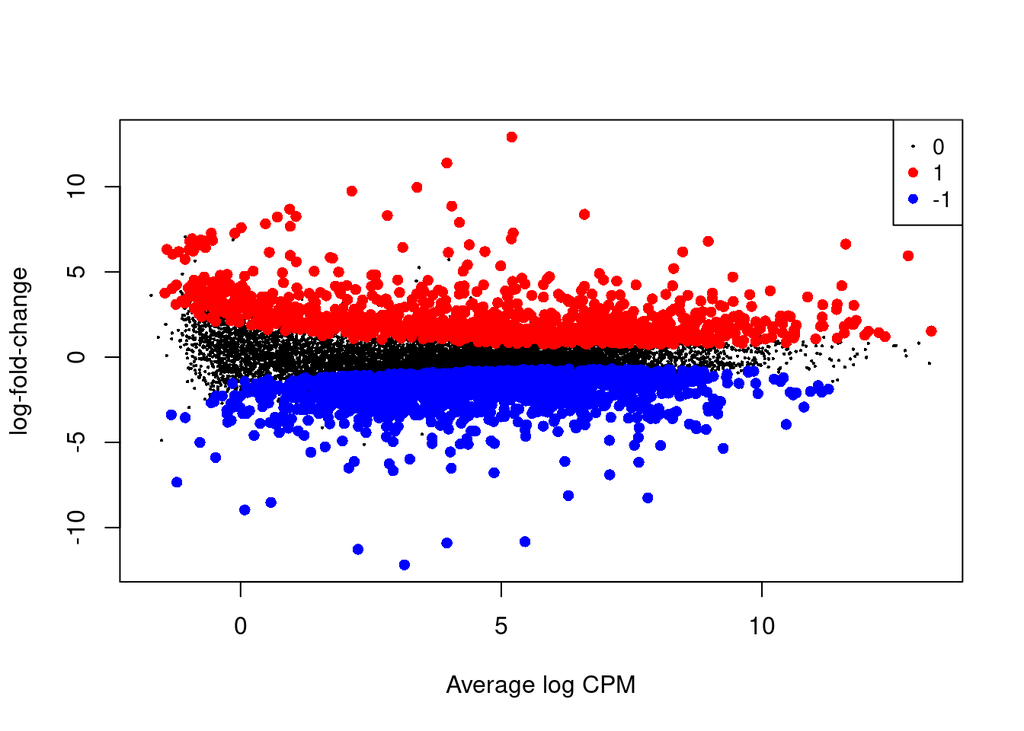

Figure 14: Alkanes_D2 vs C16_D3

```r
# The first part of the pair is the control of the comparison
contrast_pairs <- list(c("C16_D3", "Alkanes_D3"), c("Alkanes_D2", "Alkanes_D3"), c("C16_D3","Alkanes_D2"))

### Run exactTest

for (pair in contrast_pairs) {
  # I prefer the control as second
  contrast_name <- paste(pair[2], "vs", pair[1], sep = "_")
  et <- exactTest(y, pair = pair)
  # no logFC threshold
  is.de <- decideTests(et, adjust.method = "BH", p.value = 0.05, lfc = 0)
  print(summary(is.de))

  plotMD(et, status=is.de, values=c(1,-1), col=c("red","blue"), main =  "")
  # save up and downregulated genes of each comparison for enrichment analysis afterwards
  # the output of decideTests is 1 for upregulated, 0 for noDiff and -1 for downregulated
  write.table(rownames(is.de)[is.de[, paste(pair[2], pair[1], sep = "-")] == 1], file = paste("results/RNAseq/", contrast_name, "_up", sep = ""), row.names = FALSE, col.names = FALSE, quote = FALSE)
  write.table(rownames(is.de)[is.de[, paste(pair[2], pair[1], sep = "-")] == -1], file = paste("results/RNAseq/", contrast_name, "_down", sep = ""), row.names = FALSE, col.names = FALSE, quote = FALSE)

  # save dataframe with detailed DE results as well (logFC, p-value etc)
  data_de <- data.frame(topTags(et, n = et$table %>% nrow()))
  data_de$GeneID <- rownames(data_de)
  write.csv(data_de,paste( "results/RNAseq/edgeR_exactTest_", contrast_name, ".csv", sep = ""), row.names = FALSE )
}
```

## 5 Gene-ontology enrichment analysis

```bash
# bash code
# activate the conda environment where GOATOOLS is installed
source ~/miniforge3/bin/activate

# iterate over each group of DEGs and test them with GOATOOLS
for file in results/RNAseq/Alkanes_D*; do
  base_name=$(basename "$file")
  output_file="results/RNAseq/GO_${base_name}.csv"
  echo $file
  # Run GOATOOLS
  find_enrichment.py --pval=0.05 --pval_field=fdr_bh --method=fdr_bh \
                     --outfile=$output_file --ns=BP,MF --indent \
                     $file results/RNAseq/population data/functional/GOassociation | grep -v WARNING | grep -v skipped # to avoid obsolete GO terms warnings

done
```

```
results/RNAseq/Alkanes_D2_vs_C16_D3_down
go-basic.obo: fmt(1.2) rel(2024-09-08) 51,550 Terms
HMS:0:00:00.359045  17,611 annotations READ: data/functional/GOassociation BP,MF
Study: 1800 vs. Population 11964


Load BP Ontology Enrichment Analysis ...
Propagating term counts up: is_a
 38%  4,549 of 11,964 population items found in association

Load MF Ontology Enrichment Analysis ...
Propagating term counts up: is_a
 56%  6,657 of 11,964 population items found in association

Runing BP Ontology Analysis: current study set of 1800 IDs.
 34%    617 of  1,800 study items found in association
100%  1,800 of  1,800 study items found in population(11964)
Calculating 1,884 uncorrected p-values using fisher_scipy_stats
   1,884 terms are associated with  4,549 of 11,964 population items
     835 terms are associated with    617 of  1,800 study items
  METHOD fdr_bh:
      10 GO terms found significant (< 0.05=alpha) (  0 enriched +  10 purified): statsmodels fdr_bh
       0 study items associated with significant GO IDs (enriched)
     304 study items associated with significant GO IDs (purified)

Runing MF Ontology Analysis: current study set of 1800 IDs.
 53%    948 of  1,800 study items found in association
100%  1,800 of  1,800 study items found in population(11964)
Calculating 1,455 uncorrected p-values using fisher_scipy_stats
   1,455 terms are associated with  6,657 of 11,964 population items
     606 terms are associated with    948 of  1,800 study items
  METHOD fdr_bh:
      22 GO terms found significant (< 0.05=alpha) (  0 enriched +  22 purified): statsmodels fdr_bh
       0 study items associated with significant GO IDs (enriched)
     478 study items associated with significant GO IDs (purified)
    181 of 3,339 results have uncorrected P-values <= 0.05=pval

     32 items WROTE: results/RNAseq/GO_Alkanes_D2_vs_C16_D3_down.csv
results/RNAseq/Alkanes_D2_vs_C16_D3_up
go-basic.obo: fmt(1.2) rel(2024-09-08) 51,550 Terms
```

[output cut: 171 more lines]

```
     372 study items associated with significant GO IDs (purified)

Runing MF Ontology Analysis: current study set of 1127 IDs.
 56%    634 of  1,127 study items found in association
100%  1,127 of  1,127 study items found in population(11964)
Calculating 1,455 uncorrected p-values using fisher_scipy_stats
   1,455 terms are associated with  6,657 of 11,964 population items
     483 terms are associated with    634 of  1,127 study items
  METHOD fdr_bh:
      12 GO terms found significant (< 0.05=alpha) (  9 enriched +   3 purified): statsmodels fdr_bh
     426 study items associated with significant GO IDs (enriched)
      51 study items associated with significant GO IDs (purified)
    179 of 3,339 results have uncorrected P-values <= 0.05=pval

     28 items WROTE: results/RNAseq/GO_Alkanes_D3_vs_C16_D3_up.csv
```

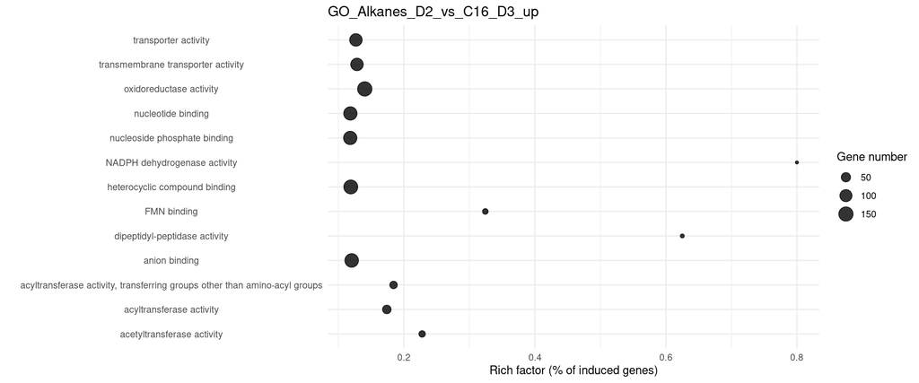

Figure 15

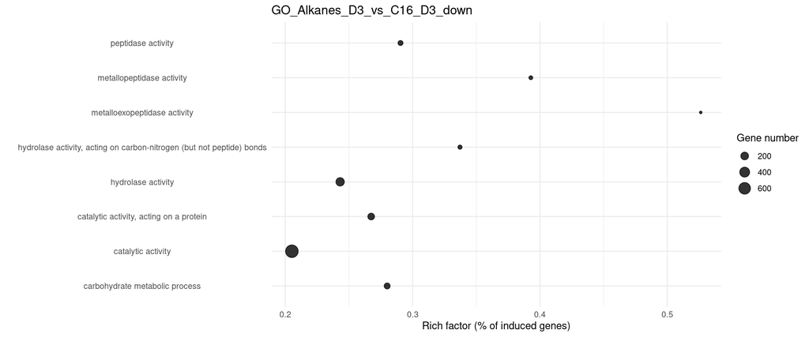

Figure 16

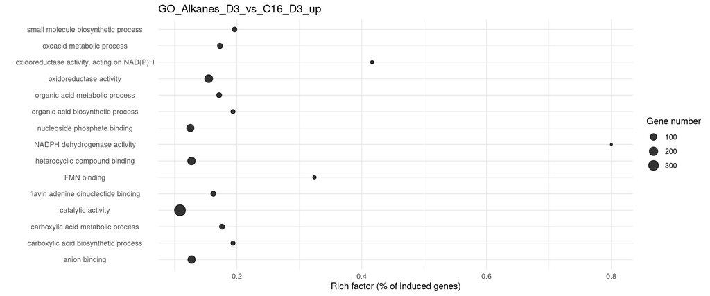

Figure 17

```r
go_files <- list.files(path = "results/RNAseq", pattern = "^GO_.*\\.csv$", full.names = TRUE)

for (file in go_files) {
  go_df  <- read.csv(file, sep = "\t", header = TRUE)
  # do not plot purified terms
  go_df <- go_df %>% filter(enrichment == "e")
  if (nrow(go_df) > 0) {
    # The ratios are given / separated, take the first part that is your count
    go_df <- go_df %>% mutate(
                            count_in_study = as.numeric(str_extract(ratio_in_study, "^[0-9]+")),
                            count_in_population = as.numeric(str_extract(ratio_in_pop, "^[0-9]+")))
    go_df$enrich_ratio <- go_df$count_in_study / go_df$count_in_population

    p <- ggplot(go_df, aes(x = enrich_ratio, y = name, size = count_in_study)) +
      geom_point(alpha = 0.8) +
      labs(
      title = strsplit(basename(file), ".", fixed = TRUE)[[1]][1],
      x = "Rich factor (% of induced genes)",
      y = "",
      size = "Gene number") +
    theme_minimal() +
    theme(axis.text.y = element_text(hjust = 0.5))

    print(p)
  }
}
```